# Criando um documento com Tufte

Fellipe

11 de dezembro de 2017

# Foco no conteúdo

Escrever relatórios é uma tarefa que faz parte do trabalho de um estatítico. Em algum momento precisamos transformar em palavras aquilo que já conhecemos em pensamentos e ninguém quer perder tempo precioso de análises em formatações de documentos.

A prática de elaborar templates de relatórios é comum entre programadores estatístics pois o foco das apresentações pode ser voltado para os resultados e diante da busca de alguma ideia de como criar um template que funcionasse em R fui buscar na página do [RStudio](https://www.rstudio.com/) e me deparei com o o pacote `tufle` disponível no [CRAN](https://cran.r-project.org)

Este pacote fornece um tamplete interessante para a elaboração de arquivos rmarkdown para converter para PDF, a apresentação é apresentada no manual mais ou menos dessa maneira:

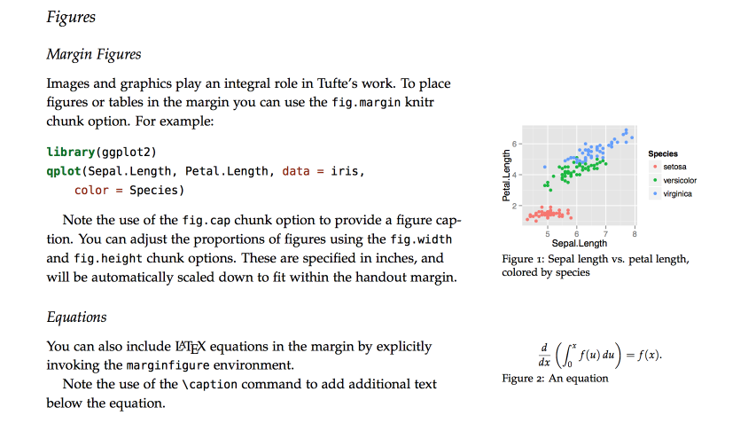

Imagem do manual

# Instalando o pacote

Para instalar o pacote, basta rodar a linha de comando:

```r
install.packages("tufte")
```

# Criando um documento documento

Para criar um documento com o novo template, basta acessae `File>New File>R Markdown...` e selecionar o templante:

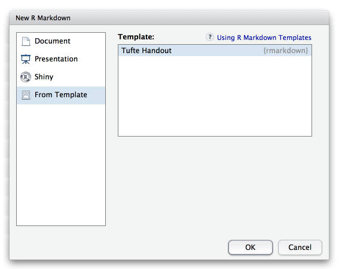

Imagem do [manual do pacote](http://rmarkdown.rstudio.com/tufte_handout_format.html#overview)

Um novo documento será aberto, caso deseje fazer alguma alteração no preâmbulo, existem essas opções apresentadas no [manual do pacote no CRAN](https://cran.r-project.org/web/packages/tufte/tufte.pdf):

# Preâmbulo do documento

```r
---
title: "Título"
subtitle: "Subtitulo"
author: "Autor"
date: "`r Sys.Date()`"
output:
  tufte::tufte_html: default
  tufte::tufte_handout:
    keep_tex: false #true
    highlight: tango #“default”, “pygments”, “kate”, “monochrome”, “espresso”, “zenburn”, and “haddock”
    fig_width: 4
    fig_height: 4
    citation_package: natbib
    latex_engine: xelatex
  tufte::tufte_book:
    citation_package: natbib
    latex_engine: xelatex
bibliography: skeleton.bib
link-citations: yes
---
```

Fornecendo algo como:

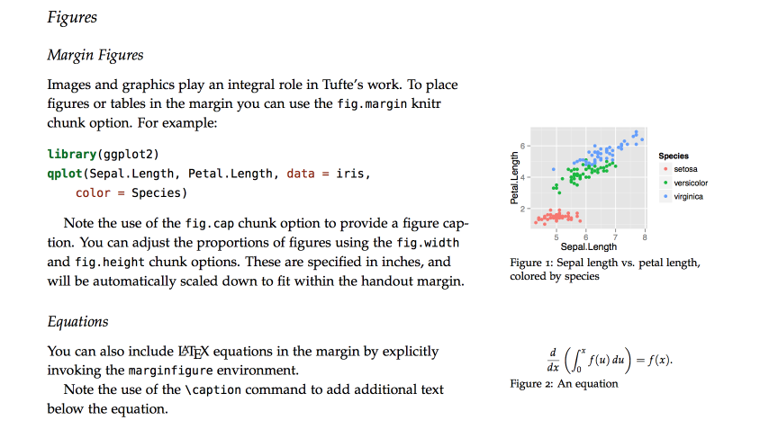